# Introduce yourself

## Команда: Andaaaaananana

# Task

In this task we are working with posts on famous russian advertisement and resell platform.

Given information about the post and corresponding item you have to estimate its probability to be sold in 3 days.

```python
# Добавляем папку на гугл-диске
from google.colab import drive
drive.mount('/content/drive')
path = "./drive/My Drive/kaggle"
```

```python
import pandas as pd
import numpy as np
import matplotlib.pyplot as plt
import sklearn
import scipy
import seaborn as sns
import warnings
warnings.filterwarnings('ignore')
from sklearn.model_selection import train_test_split,GridSearchCV,RandomizedSearchCV, cross_val_score, cross_val_predict
from sklearn.feature_extraction.text import CountVectorizer, TfidfTransformer, HashingVectorizer, TfidfVectorizer
from sklearn.metrics import *
from sklearn.ensemble import GradientBoostingClassifier, RandomForestClassifier


pd.options.mode.chained_assignment = None
%matplotlib inline
random_state = 42

plt.style.use('ggplot')
plt.rcParams['figure.figsize'] = (12,8)
```

```python
def conf_matrix(y_true, y_pred):
  return pd.DataFrame(confusion_matrix(y_true, y_pred), columns=['Predicted neg','Predicted pos'], index = ['True neg','True pos'])
```

# Data Loading

```python
df = pd.read_csv(f'{path}/train.tsv.gz', sep='\t', index_col=0)
df_test = pd.read_csv(f'{path}/test_nolabel.tsv.gz', sep='\t', index_col=0)
```

```python
# Set types of columns

def make_ints(df):
    df.delivery_available = df.delivery_available.astype('int')
    df.payment_available = df.payment_available.astype('int')

make_ints(df)

# df.date_created = pd.to_datetime(df.date_created)

def max_text_width(width=50):
    pd.set_option('display.max_colwidth', width)


max_text_width(200)
df.head(10)
```

|  | category_id | city | date_created | delivery_available | desc_text | img_num | lat | long | name_text | owner_id | payment_available | price | product_id | product_type | properties | region | sold_mode | subcategory_id | sold_fast |
| --- | --- | --- | --- | --- | --- | --- | --- | --- | --- | --- | --- | --- | --- | --- | --- | --- | --- | --- | --- |
| 1 | 4 | Краснодар | 2018-10-08 | 0 | Продаю стол раскладной, деревянный, советский на века. Состояние осень хорошее. Торг уместен. Самовывоз ФМР | 3 | 45.0686 | 38.9518 | Стол | 4ce583fe8231a0cc4a3c7d241c7d0289 | 1 | 500.0 | 8cb80c05c65c210275f5500779d6b593 | 1 | [{'slug_id': 'stoly_stulya_tip', 'slug_name': 'Тип', 'value': 'Столы', 'value_id': 9490}] | Краснодарский край | 1 | 410 | 1 |
| 2 | 4 | Тюмень | 2018-06-18 | 0 | Тарелки глубокие 6 шт. Блюдца, чашки по 6 шт. Все ранешний фарфор. В другом пакете современные блюдца, чашки и чайник с мишкой Тедди. Ничем практически не пользовались | 2 | 57.1840 | 65.5674 | Посуда | e58be2c8f143c17246dc2243b5d3b98f | 0 | 300.0 | 3b7a9f8b27a53b63525f95bc8070abb2 | 1 | [{'slug_id': 'dom_dacha_posuda_tip', 'slug_name': 'Тип', 'value': 'Тарелки', 'value_id': 9461}] | Тюменская область | 1 | 405 | 0 |
| 4 | 9 | Омск | 2018-07-31 | 1 | Новый,с этикеткой. Размер L. Не подошёл по размеру,маломерит на размер. Померить можно ул. 25 Линия 74. В любое удобное для вас время. | 1 | 54.9889 | 73.4312 | Костюм | 51b408796027214232532b7e478e2159 | 1 | 1100.0 | c97dd9c5a3e938c52cf5d7822bc0eb7b | 1 | [{'slug_id': 'zhenskaya_odezhda_pidzhaki_kostyumy_tip', 'slug_name': 'Тип', 'value': 'Костюмы с юбкой', 'value_id': 8362}, {'slug_id': 'zhenskaya_odezhda_razmer', 'slug_name': 'Размер', 'value': '... | Омская область | 1 | 908 | 0 |
| 6 | 3 | Санкт-Петербург | 2018-04-17 | 0 | Складывается тростью, все колеса вниз. Сплошная ручка, сама стоит в сложенном виде, капюшон закрывает до бампера, передние колеса одинарные, по снегу и каше едут. Это аналог пег перего си, только ... | 4 | 59.9590 | 30.4877 | Коляска | 6544b83acbbf04439a7ba983093cafb4 | 1 | 5000.0 | 3e5d0286b25fd7f62f88bc436a59ae4e | 1 | [{'slug_id': 'waggon_type', 'slug_name': 'Тип', 'value': 'Прогулочная', 'value_id': 8615}, {'slug_id': 'waggon_max_age', 'slug_name': 'Возраст', 'value': 'До 3 лет', 'value_id': 8620}] | Ленинградская область | 1 | 312 | 0 |
| 10 | 5 | Москва | 2018-02-09 | 0 | Неразлучники, птичкам по 1,5 года. Продаю с большой клеткой, кормушками и поилкой | 2 | 55.6473 | 37.4118 | Волнистые попугаи | ea575e28daf1f47bfce63015cd3ce5cf | 1 | 2000.0 | 57b4a8679d0d3eb1e31367b57221098f | 1 | [] | Московская область | 1 | 504 | 0 |
| 11 | 11 | Гусь-Хрустальный | 2018-04-28 | 0 | Продам детский велосипед,двухколесный,лет для 5-6ти. Маленьких боковых колес нет. | 1 | 55.6063 | 40.6564 | Велосипед детский | 9ba6bb7a01bf0e577a36682da64a5dde | 1 | 800.0 | c73fd3f12f71c73ad4fa9c1b4b4f3629 | 1 | [{'slug_id': 'sport_tzvet', 'slug_name': 'Цвет', 'value': 'Зеленый', 'value_id': 10188}, {'slug_id': 'velosipedy_tip', 'slug_name': 'Тип', 'value': 'Городские, дорожные', 'value_id': 10173}] | Владимирская область | 1 | 1107 | 0 |
| 12 | 5 | Якутск | 2018-02-08 | 0 | Отдам кота, 8 месяцев, к горшку приучен. | 1 | 62.0355 | 129.6755 | скоттиш страйт | 7e0e13efb64cfbb1daf62a87ed63bf1f | 0 | 1.0 | be19161f29cc7e6e1795f756ef9e29e0 | 1 | [{'slug_id': 'koshki_poroda', 'slug_name': 'Порода', 'value': 'Шотландская', 'value_id': 10437}] | Республика Саха (Якутия) | 1 | 503 | 0 |
| 13 | 13 | Краснодар | 2018-10-14 | 0 | ТВ в рабочем состоянии | 3 | 45.0618 | 38.9170 | LE32R72B | e8e578f2dd291cc1b2e5944cb869028a | 0 | 6000.0 | c76ee67dfc81c0f06a3d908370a2f59e | 1 | [{'slug_id': 'televizory_marka', 'slug_name': 'Марка', 'value': 'Samsung', 'value_id': 9612}, {'slug_id': 'televizory_tip', 'slug_name': 'Тип', 'value': 'ЖК, LED', 'value_id': 9588}, {'slug_id': '... | Краснодарский край | 1 | 1302 | 0 |
| 14 | 25 | Орск | 2018-06-02 | 0 | 1991 г.в.Пробег около 20000 км. Документы есть. Полностью на ходу. | 2 | 51.2585 | 58.6035 | Минск | a992d673ee26064a0e9d157296244739 | 0 | 15000.0 | c19620c06a40e40445854c4f665416da | 1 | [{'slug_id': 'motocikly_skutery_tip', 'slug_name': 'Тип', 'value': 'Дорожные мотоциклы', 'value_id': 11382}] | Оренбургская область | 1 | 2503 | 0 |
| 15 | 2 | Москва | 2018-06-20 | 0 | Продаю срочно бу хорошем состоянии два по 1.5 метра витрина и шкаф большой для воды | 3 | 55.8134 | 37.5958 | Холодильники бу | fd9f4d97a20b9d279de9b45ba78d5874 | 1 | 12000.0 | 22670ae3efc3d73a3bec355ce05561ea | 1 | [{'slug_id': 'oborudovanie_tip', 'slug_name': 'Тип', 'value': 'Пищевое, холодильное', 'value_id': 10826}] | Московская область | 1 | 202 | 0 |

```python
len(df),len(df_test)
```

```
(351281, 89251)
```

```python
df.sort_values(by='date_created').head()
```

|  | category_id | city | date_created | delivery_available | desc_text | img_num | lat | long | name_text | owner_id | payment_available | price | product_id | product_type | properties | region | sold_mode | subcategory_id | sold_fast |
| --- | --- | --- | --- | --- | --- | --- | --- | --- | --- | --- | --- | --- | --- | --- | --- | --- | --- | --- | --- |
| 221737 | 12 | Архангельск | 2018-01-01 | 1 | iPhone 5 c желтого цвета в отличном состоянии,в подарок силиконовый прозрачный чехол. | 2 | 64.5389 | 40.5404 | iPhone 5 c | 0c98f60d0b5e22fac72460479ab2ef51 | 1 | 5500.0 | 60a814a6806be7fb22b89a52f789b91f | 1 | [{'slug_id': 'phone_brand', 'slug_name': 'Марка', 'value': 'Apple', 'value_id': 8889}, {'slug_id': 'smartfony_os', 'slug_name': 'Операционная система', 'value': 'iOS', 'value_id': 8930}, {'slug_id... | Архангельская область | 1 | 1202 | 1 |
| 380921 | 12 | Химки | 2018-01-01 | 1 | Процессор: 1300 Мгц (4-ядерный), граф.процессор Память: 4 Гб + 32 Гб, 512 Мб RAM, microSDHC, microSD Платформа: Android 4.2 Аккумулятор: 2000 мА*ч Li-Ion, 13 ч разг.(GSM), 9 ч разг.(WCDMA) Экран: ... | 4 | 55.8786 | 37.4247 | Смартфон Alcatel 7041d | 2ac5c9ad2db6f768866617027c1c7872 | 1 | 1500.0 | 2b63b6e7801993186e12c98481bec1fc | 1 | [{'slug_id': 'smartfony_slot_dlya_karty_pamyaty', 'slug_name': 'Слот для карты памяти', 'value': 'Есть', 'value_id': 8948}, {'slug_id': 'smartfony_kolichestvo_sim_kart', 'slug_name': 'Количество S... | Московская область | 1 | 1202 | 1 |
| 202514 | 2 | Новокузнецк | 2018-01-01 | 0 | Стиралка и центрифуга ФЕЯ. НА ДАЧУ, ВСЁ В РАБОЧЕМ СОСТОЯНИИ. СТОИТ БЕЗ ДЕЛА. | 3 | 53.8346 | 87.1962 | ФЕЯ - 2 | 2cf71c0e569fbc2c8e27baf355119980 | 0 | 1000.0 | f7cba720bb7c713f3356f85410b75ccf | 1 | [] | Кемеровская область | 1 | 208 | 0 |
| 261414 | 15 | Нижний Тагил | 2018-01-01 | 0 | Видеокарта на 1 GB В отличном состоянии | 1 | 57.9136 | 59.9734 | Geforce 210 1gb | adf8a79665003f75c58c0d9da120488b | 1 | 1000.0 | db0676571b71324354300c26aed4874a | 1 | [{'slug_id': 'kompjuteri_komplektuyushchie_ustrojstvo', 'slug_name': 'Устройство', 'value': 'Для компьютеров', 'value_id': 9400}, {'slug_id': 'kompjuteri_komplektuyushchie_tip', 'slug_name': 'Тип'... | Свердловская область | 1 | 1508 | 1 |
| 368416 | 15 | Москва | 2018-01-01 | 0 | Мать: Asus P8H77-M PRO Процессор: Intel Core i7-3770 3,4Ghz Память: Kingston 8Gb DDR3 1333Mhz Видео: Asus GeForce GT240 Корпус Asus midi tower 450 ватт SSD 120Gb + HDD 500Gb | 1 | 55.8584 | 37.5033 | Системный блок | 39d6d4a848aca2408c364336d2cf22e7 | 1 | 20000.0 | 0f5ed5c414e39cf99ea276d4d0289ecb | 1 | [{'slug_id': 'kompyutery_tip', 'slug_name': 'Тип', 'value': 'Настольные, системные блоки', 'value_id': 9262}] | Московская область | 1 | 1502 | 0 |

# Descriptive Data Analysis

- Analyze train dataset features
  - Provide some meaningfull description about corresponding features (in form of pictures or some coefficients)
  - Outline any findings you are able to reveal
- Try to measure analyse any correspondense between features and target features

```python
# Соотношение числа представителей классов

print('positive:', sum(df.sold_fast == 1))
print('negative:', sum(df.sold_fast == 0))
print('ratio:', np.mean(df.sold_fast))
```

```
positive: 81080
negative: 270201
ratio: 0.23081236958446372
```

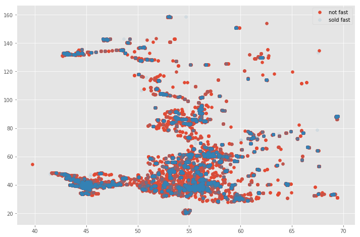

```python
# Геопозиция и скорость продаж - не похоже что сильно связаны
df0 = df[df.sold_fast == 0]
df1 = df[df.sold_fast == 1]
plt.scatter(x='lat', y='long', data=df0,alpha=1,label='not fast')
plt.scatter(x='lat', y='long', data=df1,alpha=0.1,label='sold fast')
plt.legend();
```

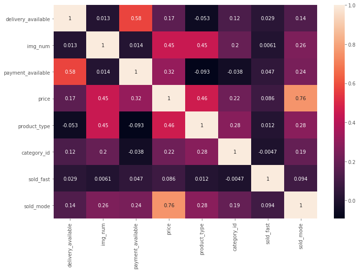

```python
df2 = df[['delivery_available','img_num','payment_available','price','product_type','category_id','sold_fast','sold_mode']]
df2.loc[df2.price== 0,:] = 0.0001
df2.loc[:,'price'] = np.log10(df2.loc[:,'price'])
sns.heatmap(df2.corr(),annot=True)
```

Цена и скорость продажи - при высокой цене продукты не очень быстро продаются, но в среднем не очень связаны

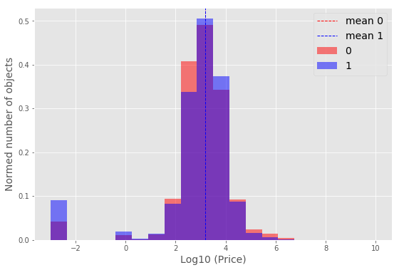

```python
df.loc[df.price== 0,'price'] = 0.001
feature_values = np.log10(df.price.values)
labels = df.sold_fast.values
feature_values_notnull = feature_values[feature_values!=-3]
labels_notnull = labels[feature_values!=-3]

plt.figure(figsize=(9, 6))
bins = np.linspace(-3, 10, 21)

plt.hist(feature_values[labels == 0], bins=bins, label='0', color='r', alpha=0.5, density=True)
plt.hist(feature_values[labels == 1], bins=bins, label='1', color='b', alpha=0.5, density=True)
plt.axvline(feature_values_notnull[labels_notnull == 1].mean(), color='r', linestyle='dashed', linewidth=1,label='mean 0')
plt.axvline(feature_values_notnull[labels_notnull == 0].mean(), color='b', linestyle='dashed', linewidth=1,label='mean 1')

plt.ylabel('Normed number of objects', size=14)
plt.xlabel('Log10 (Price)', size=14)
plt.legend(loc='best', fontsize=14)
plt.grid(b=1)
plt.show()
```

## Work with cities

```python
pd.DataFrame(df.groupby('region').sold_fast.mean().sort_values(ascending=False)).head()#.where(lambda x : (x<1) & (x>0)).dropna()
```

| region | sold_fast |
| --- | --- |
| Абинск | 1.0 |
| Электросталь | 1.0 |
| Бор | 1.0 |
| Череповец | 1.0 |
| Челябинск | 1.0 |

```python
pd.DataFrame(df.groupby('category_id').sold_fast.mean().sort_values(ascending=False)).head()#.where(lambda x : (x<1) & (x>0)).dropna()
```

| category_id | sold_fast |
| --- | --- |
| 2 | 0.328338 |
| 12 | 0.293339 |
| 13 | 0.275721 |
| 15 | 0.263248 |
| 10 | 0.260657 |

Добавляем перевод названий городов на английский (Yandex-transtate)

```python
# save cities
cities = df.city.unique()
#np.savetxt('cities.txt', cities,'%s')

# load translated city names(by Yandex-translate:)
translated = pd.read_table(f'{path}/translated_cities.txt',header=None)
translated.columns = ['city_en']
city = pd.concat([translated, pd.Series(cities,name='city')],axis=1)
city.head()
```

|  | city_en | city |
| --- | --- | --- |
| 0 | Krasnodar | Краснодар |
| 1 | Tyumen | Тюмень |
| 2 | Omsk | Омск |
| 3 | Saint-Petersburg | Санкт-Петербург |
| 4 | Moscow | Москва |

Была идея вычислять расстояние до центра города и nominatim как раз умеет возвращать координаты по названию города, а geopy - считать расстояние в километрах, но он не дает это делать, т.к. число городов у нас больше установленного максимального числа запросов

```python
from geopy.geocoders import Nominatim
from geopy.distance import geodesic

# получаем координаты
#geolocator = Nominatim()
#locatio n = geolocator.geocode("Omsk")
#pos = (location.latitude, location.longitude)
#print(location, pos)

# cчитаем расстояние
#place = df[df.city == 'Омск'].iloc[121]
#distance = geodesic(pos,(place.lat, place.long))
#print(distance.km)

def get_location(name):
    geolocator = Nominatim()
    location = geolocator.geocode(name)
    if location is None:
        return 0
    else:
        return (location.latitude, location.longitude)
#locations = list(map(get_location,city.city_en.values))
#city.location = locations
```

### Adding city population

Добавляем данные о населении городов и регионов из нескольких источников, т.к. все данные не очень полные

Добавляем данные с википедии https://en.wikipedia.org/wiki/List_of_cities_and_towns_in_Russia_by_population

```python
city_population = pd.read_excel(f'{path}/city_population_2010_plus_crimea.xlsx')
city_population = city_population[['Город', 'Население']].dropna()
city_population.columns = ['city', 'population']
city_population = {row.city:row.population for _, row in city_population.iterrows()}
```

```python
# city_population.sort_values('population', ascending=False).head()
sorted(city_population.items(), key=lambda kv: -kv[1])[:10]
```

```
[('Москва', 11514330),
 ('Санкт-Петербург', 4848742),
 ('Новосибирск', 1498921),
 ('Екатеринбург', 1377738),
 ('Нижний Новгород', 1250615),
 ('Казань', 1216965),
 ('Самара', 1164900),
 ('Омск', 1154000),
 ('Челябинск', 1130273),
 ('Ростов-на-Дону', 1091544)]
```

Добавляем данные из датасета на kaggle "Russian city population" https://www.kaggle.com/stecasasso/russian-city-population

```python
city_population_another = pd.read_csv(f'{path}/city_population.csv')
city_population_another.population = city_population_another.population.astype(int)
city_population_another = {row.city:row.population for _, row in city_population_another.iterrows()}

city_population_another['Большая Орловка'] = 4063
city_population_another['Орловка'] = 847
city_population_another['Александрия'] = 82410
```

```python
sorted(city_population_another.items(), key=lambda kv: -kv[1])[:10]
```

```
[('Центральный', 39311413),
 ('Керчевский', 25003000),
 ('Тимирязевский', 12506468),
 ('Новосибирск', 1602915),
 ('Сибирский', 1602915),
 ('Николаевская', 1602915),
 ('Екатеринбург', 1455904),
 ('Артышта', 1312614),
 ('Нижний Новгород', 1264075),
 ('Советск', 1264075)]
```

```python
# merging
city_population_merged = city_population_another.copy()
city_population_merged.update(city_population)
```

```python
# функции для подсчета найденных и ненайденных данных о городах и регионах
def how_much_found(population):
    cities = df.city.unique()

    found = [city for city in cities if city in population]
    not_found = [city for city in cities if city not in population]

    print('found:', len(found))
    print('not found:', len(not_found))
    return not_found

def how_much_found_region(population):
    cities = df.region.unique()

    found = [city for city in cities if city in population]
    not_found = [city for city in cities if city not in population]

    print('found:', len(found))
    print('not found:', len(not_found))
    return not_found

how_much_found(city_population_merged);
how_much_found_region(city_population_merged);
```

```
found: 1611
not found: 688
found: 26
not found: 83
```

Добавляем данные Росстата www.gks.ru/free_doc/new_site/population/demo/perepis2010/svod.xls

```python
svod_population = pd.read_excel(f'{path}/svod_population.xls', skiprows=4, names=['city', 'population']).dropna()
svod_population.city = svod_population.city.apply(lambda x: x.replace('г.', '')
                                                  .replace('пгт ', '')
                                                  .replace('рп ', '')
                                                  .replace('(рц)','')
                                                  .replace('с подчинеными его администрации населенными пунктами','')
                                                  .replace('с подчиненными его администрации населенными пунктами','')
                                                  .replace('Городское население -','')
                                                  .replace('включая Ненецкий автономный округ','')
#                                                   .replace('Республика ','')
                                                  .replace('C', 'С') # !!!!!!!!!!!!!!
                                                  .replace('—','-')
                                                  .strip())
svod_population = svod_population[svod_population.population != '-']
svod_population.population = svod_population.population.astype(int)

svod_population = svod_population[svod_population.city != 'Городское население']
svod_population = svod_population[svod_population.city != 'Сельское население']
svod_population = {row.city:row.population for _, row in svod_population.iterrows()}
# svod_population.pop('Городское население')
# svod_population.pop('Сельское население')
len(svod_population)
```

```
4443
```

```python
sorted(svod_population.items(), key=lambda kv: kv[0])[:10]
```

```
[('Абаза', 17111),
 ('Абазинский район', 17189),
 ('Абакан', 165183),
 ('Абанский район', 22580),
 ('Абатский район', 19838),
 ('Абдулино', 20183),
 ('Абдулинский район', 10373),
 ('Абзелиловский район', 45545),
 ('Абинск', 34926),
 ('Абинский район', 91905)]
```

```python
city_population_merged.update(svod_population)
```

```python
how_much_found(city_population_merged);
```

```
found: 1894
not found: 405
```

```python
how_much_found_region(city_population_merged)
```

```
found: 91
not found: 18
```

```
['Тюменская область',
 'Адыгея',
 'Башкортостан',
 'Удмуртия',
 'Дагестан',
 'Республика Крым',
 'Татарстан',
 'Кабардино-Балкария',
 'Чувашия',
 'Мордовия',
 'Северная Осетия',
 'Марий Эл',
 'Карачаево-Черкесия',
 'Чечня',
 'Калмыкия',
 'Россия',
 'Ингушетия',
 'Биокомбината']
```

Добавляем новые фичи в датасет - city_population и region_population

```python
mean_city = int(np.median(list(city_population_merged.values())))


def get_population(cities, mean_city):
    return [city_population_merged[city] if city in city_population_merged else mean_city for city in cities]


def add_city_region_population(df):
    population_col = get_population(df.city, mean_city)
    population_col_region = get_population(df.region, 1_900_000) # crimea population as default
    df['city_population'] = population_col
    df['region_population'] = population_col_region

add_city_region_population(df)
```

```python
max_text_width(20)
df.head()
```

|  | category_id | city | date_created | delivery_available | desc_text | img_num | lat | long | name_text | owner_id | payment_available | price | product_id | product_type | properties | region | sold_mode | subcategory_id | sold_fast | city_population | region_population |
| --- | --- | --- | --- | --- | --- | --- | --- | --- | --- | --- | --- | --- | --- | --- | --- | --- | --- | --- | --- | --- | --- |
| 1 | 4 | Краснодар | 2018-10-08 | 0 | Продаю стол раск... | 3 | 45.0686 | 38.9518 | Стол | 4ce583fe8231a0cc... | 1 | 500.0 | 8cb80c05c65c2102... | 1 | [{'slug_id': 'st... | Краснодарский край | 1 | 410 | 1 | 744933 | 5225826 |
| 2 | 4 | Тюмень | 2018-06-18 | 0 | Тарелки глубокие... | 2 | 57.1840 | 65.5674 | Посуда | e58be2c8f143c172... | 0 | 300.0 | 3b7a9f8b27a53b63... | 1 | [{'slug_id': 'do... | Тюменская область | 1 | 405 | 0 | 581758 | 1900000 |
| 4 | 9 | Омск | 2018-07-31 | 1 | Новый,с этикетко... | 1 | 54.9889 | 73.4312 | Костюм | 51b4087960272142... | 1 | 1100.0 | c97dd9c5a3e938c5... | 1 | [{'slug_id': 'zh... | Омская область | 1 | 908 | 0 | 1153971 | 1977450 |
| 6 | 3 | Санкт-Петербург | 2018-04-17 | 0 | Складывается тро... | 4 | 59.9590 | 30.4877 | Коляска | 6544b83acbbf0443... | 1 | 5000.0 | 3e5d0286b25fd7f6... | 1 | [{'slug_id': 'wa... | Ленинградская об... | 1 | 312 | 0 | 4848742 | 1712690 |
| 10 | 5 | Москва | 2018-02-09 | 0 | Неразлучники, пт... | 2 | 55.6473 | 37.4118 | Волнистые попугаи | ea575e28daf1f47b... | 1 | 2000.0 | 57b4a8679d0d3eb1... | 1 | [] | Московская область | 1 | 504 | 0 | 11514330 | 7092941 |

## Plots

связано ли кол-во выставляемых товаров продавцами со скоростью продаж

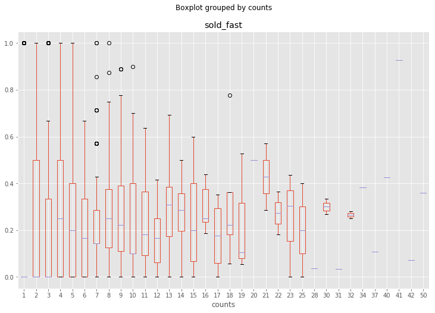

```python
owners = df.groupby(by='owner_id').sold_fast.mean()
counts = df.owner_id.value_counts()
owners_counts = pd.DataFrame({'sold_fast':owners,'counts':counts}).sort_values('counts',ascending =  False)
owners_counts.boxplot('sold_fast','counts')
#owners_counts
```

Получим категории и субкатегории, которые быстрее всего раскупаются

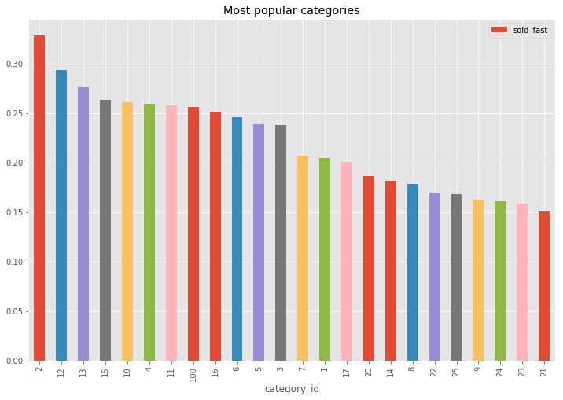

```python
cat = df.groupby(by='category_id').sold_fast.mean()
cat = pd.DataFrame(cat).sort_values(by='sold_fast',ascending=False)
cat.plot.bar(y='sold_fast')
plt.title('Most popular categories')
```

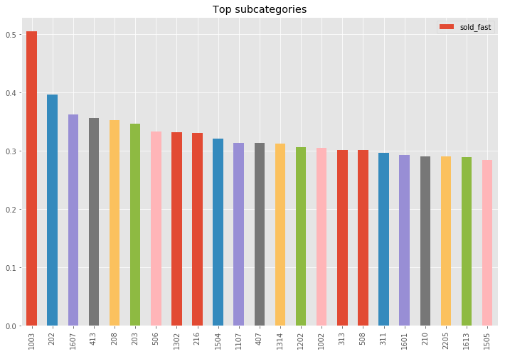

```python
subcat = df.groupby(by='subcategory_id').sold_fast.mean()
counts = df.subcategory_id.value_counts()
subcat = pd.DataFrame({'sold_fast':subcat,'counts':counts})
subcat = subcat.sort_values(by=['sold_fast'],ascending=False).head(30)
subcat = subcat[subcat.counts >= 50]
subcat.plot.bar(y='sold_fast')
plt.title('Top subcategories')
```

Посмотрим на быстро раскупаемые товары и в каких регионах и городах они чаще

```python
def get_sold_fast(feature, top = 25, min_ratio = None, dataframe = False):
    fig,ax = plt.subplots()

    feat = df.groupby(by=['sold_fast',feature])[feature].count()
    feat_sold_fast = feat[1]
    feat_sold_fast = pd.DataFrame({'count_sold_fast':feat_sold_fast})
    feat_sold_fast = feat_sold_fast.sort_values(by='count_sold_fast',ascending=False)


    count = df[feature].value_counts()
    count.name = 'count_all'
    feat_sold_fast = feat_sold_fast.join(count)
    feat_sold_fast.head(top).plot.bar(y='count_all',ax=ax,color='black',alpha=0.2)
    feat_sold_fast.head(top).plot.bar(y='count_sold_fast',ax=ax)
    plt.title(f'Top {feature} by number of sold_fast')

    #feat_sold_fast = feat_sold_fast[feat_sold_fast.count_all > 50]
    feat_sold_fast.loc[:,'ratio'] = feat_sold_fast.count_sold_fast / feat_sold_fast.count_all
    feat_sold_fast = feat_sold_fast.sort_values(by='ratio',ascending=False)

    if dataframe:
        return feat_sold_fast.head(top)
    elif min_ratio is not None:
        feat_sold_fast = feat_sold_fast[feat_sold_fast.ratio>min_ratio]
        return feat_sold_fast
    else:
        feat_sold_fast = feat_sold_fast.head(top)
        feat_sold_fast.plot.bar(y='ratio')
        plt.title(f'Top {feature} by ratio sold_fast/all')
        #feat_sold_fast = feat_sold_fast.sort_values(by='counts_all',ascending=False)
        #feat_sold_fast_top_ratio.plot.bar(y='count_all')
        #plt.title(f'Top {feature} by ratio sold_fast/all - number')
```

```python
def get_heatmap(feature):
    feat = df.groupby(by=['sold_fast',feature])[feature].count()
    sns.heatmap(feat.unstack(),annot=True,fmt='.2f',cmap='rocket_r')
```

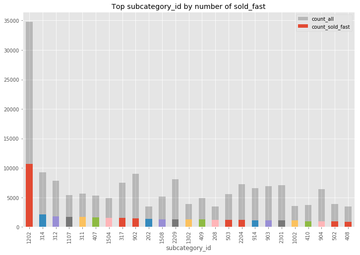

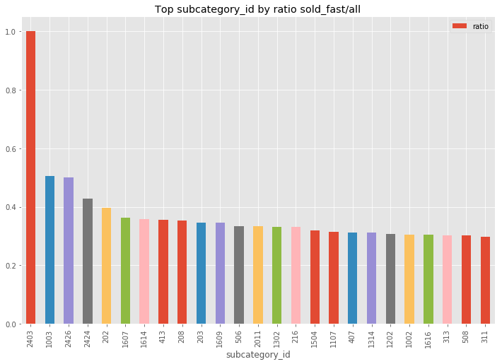

```python
get_sold_fast('subcategory_id')
```

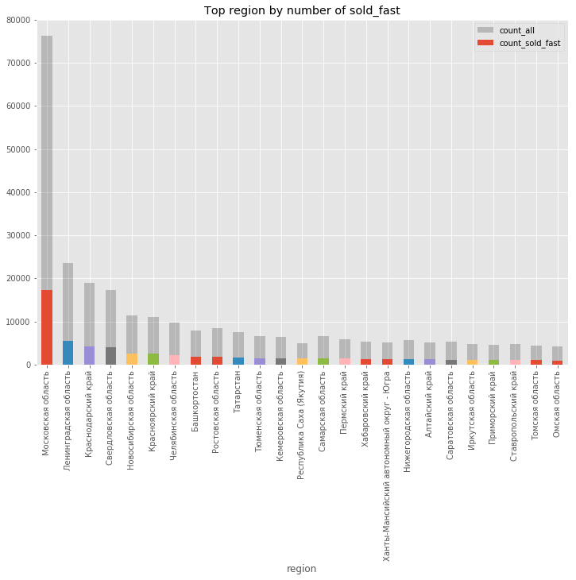

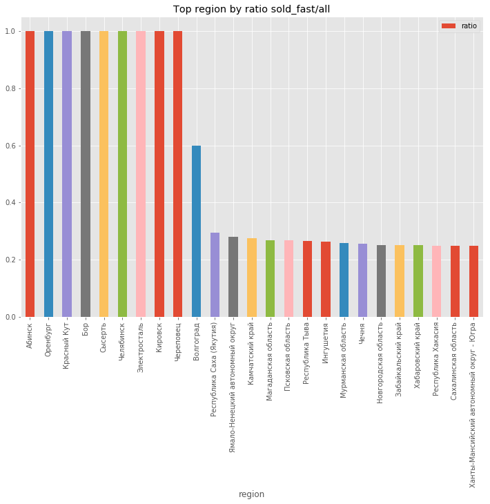

```python
get_sold_fast('region')
```

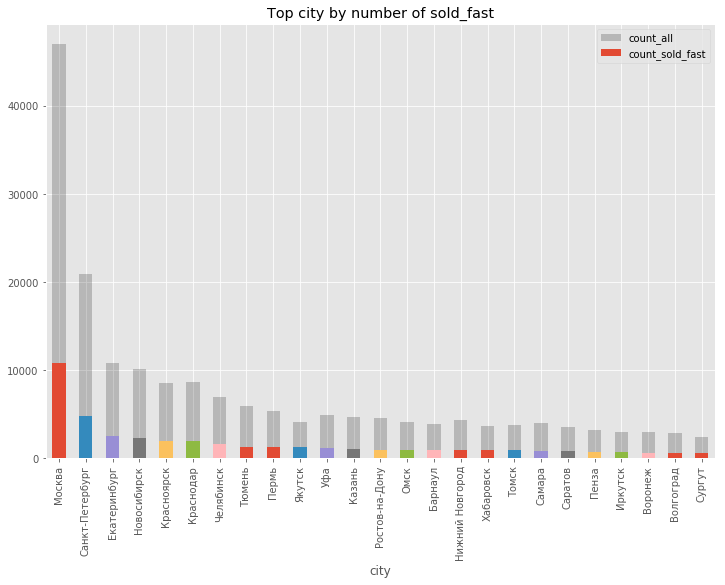

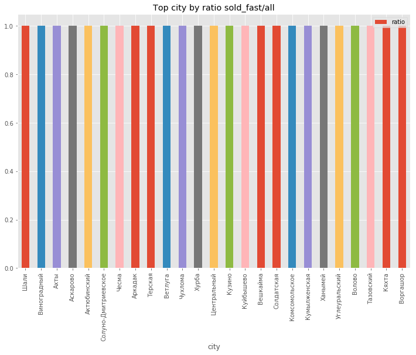

```python
get_sold_fast('city')
```

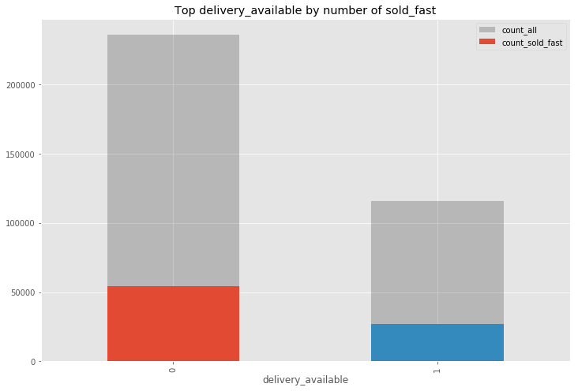

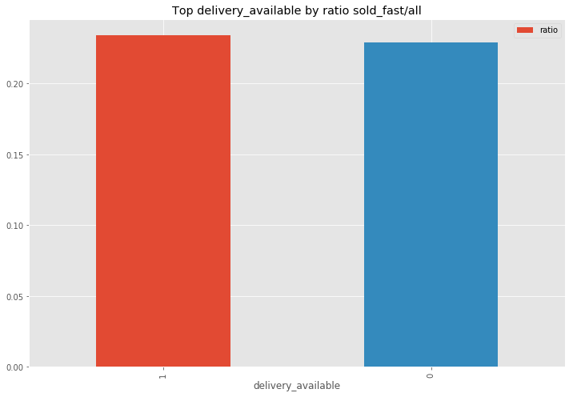

```python
get_sold_fast('delivery_available')
```

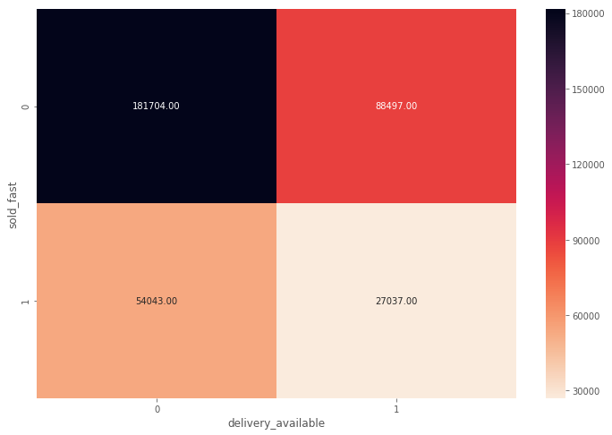

```python
get_heatmap('delivery_available')
```

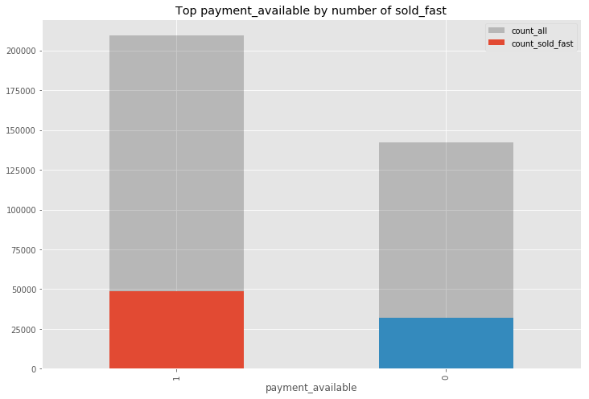

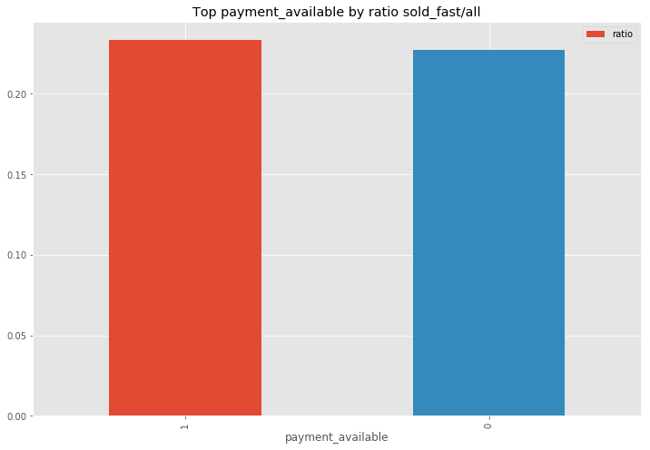

```python
get_sold_fast('payment_available')
```

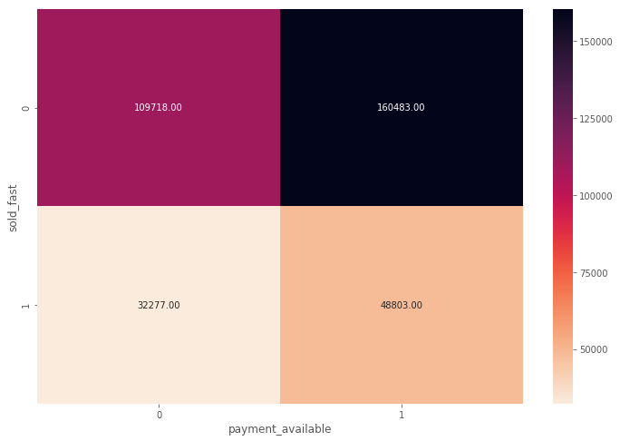

```python
get_heatmap('payment_available')
```

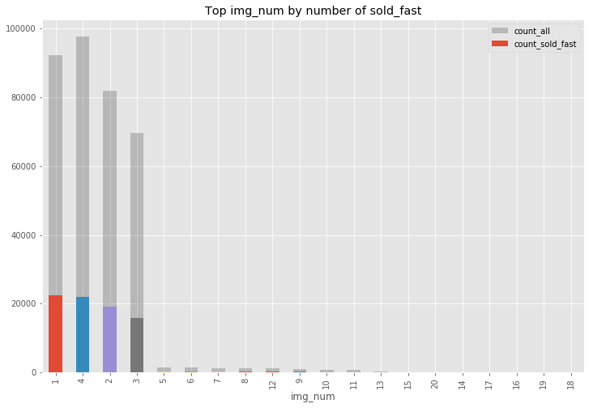

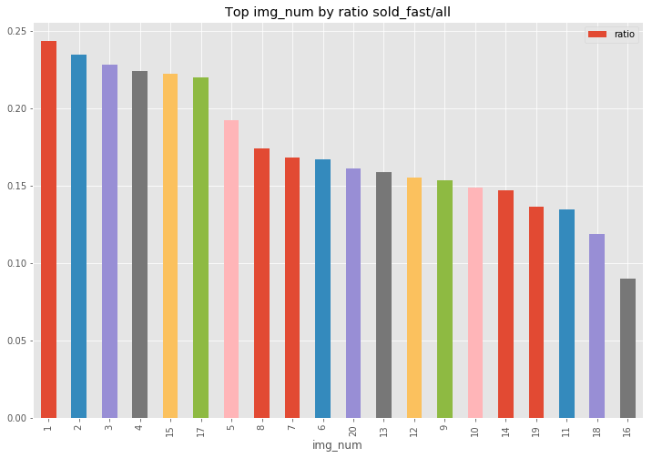

```python
get_sold_fast('img_num')
```

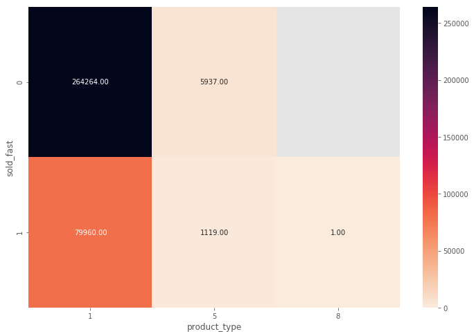

```python
get_heatmap('product_type')
```

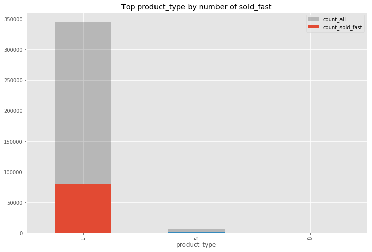

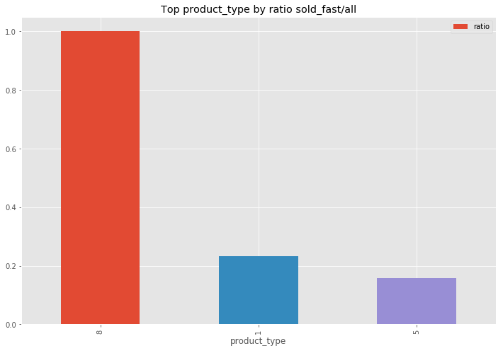

```python
get_sold_fast('product_type')
```

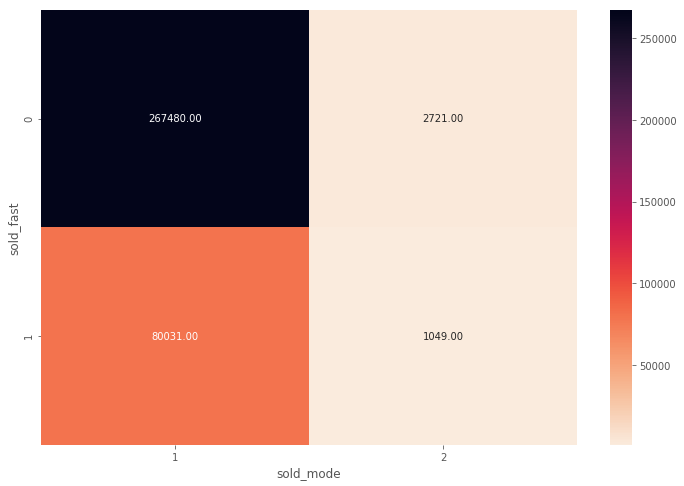

```python
get_heatmap('sold_mode')
```

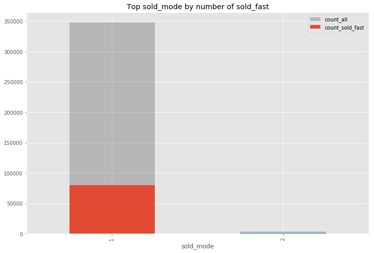

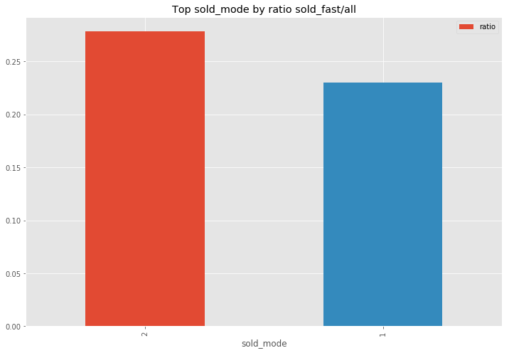

```python
get_sold_fast('sold_mode')
```

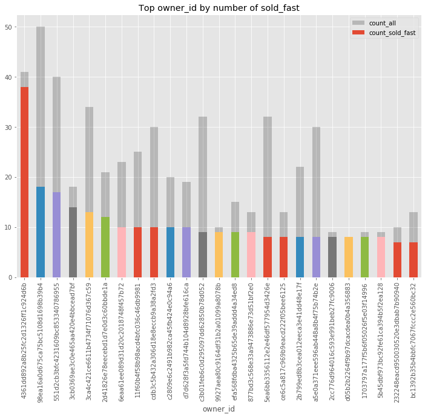

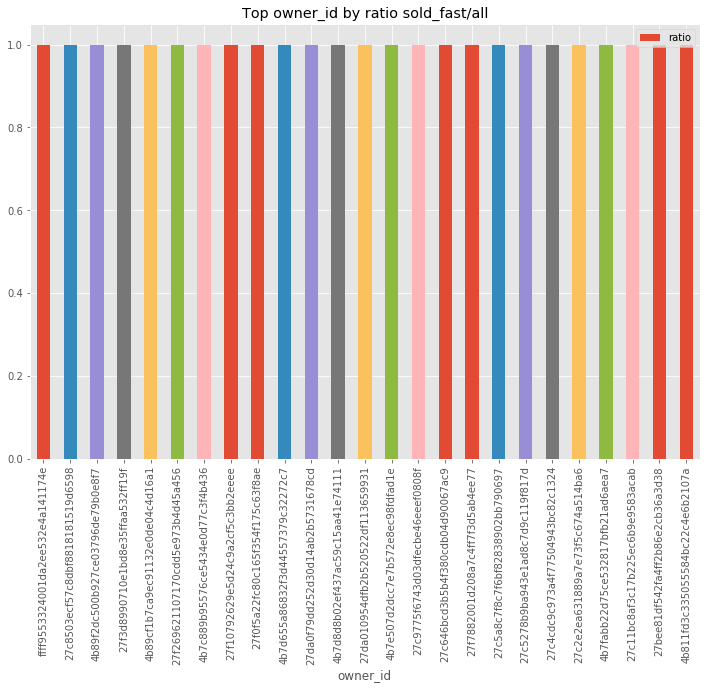

```python
get_sold_fast('owner_id')
```

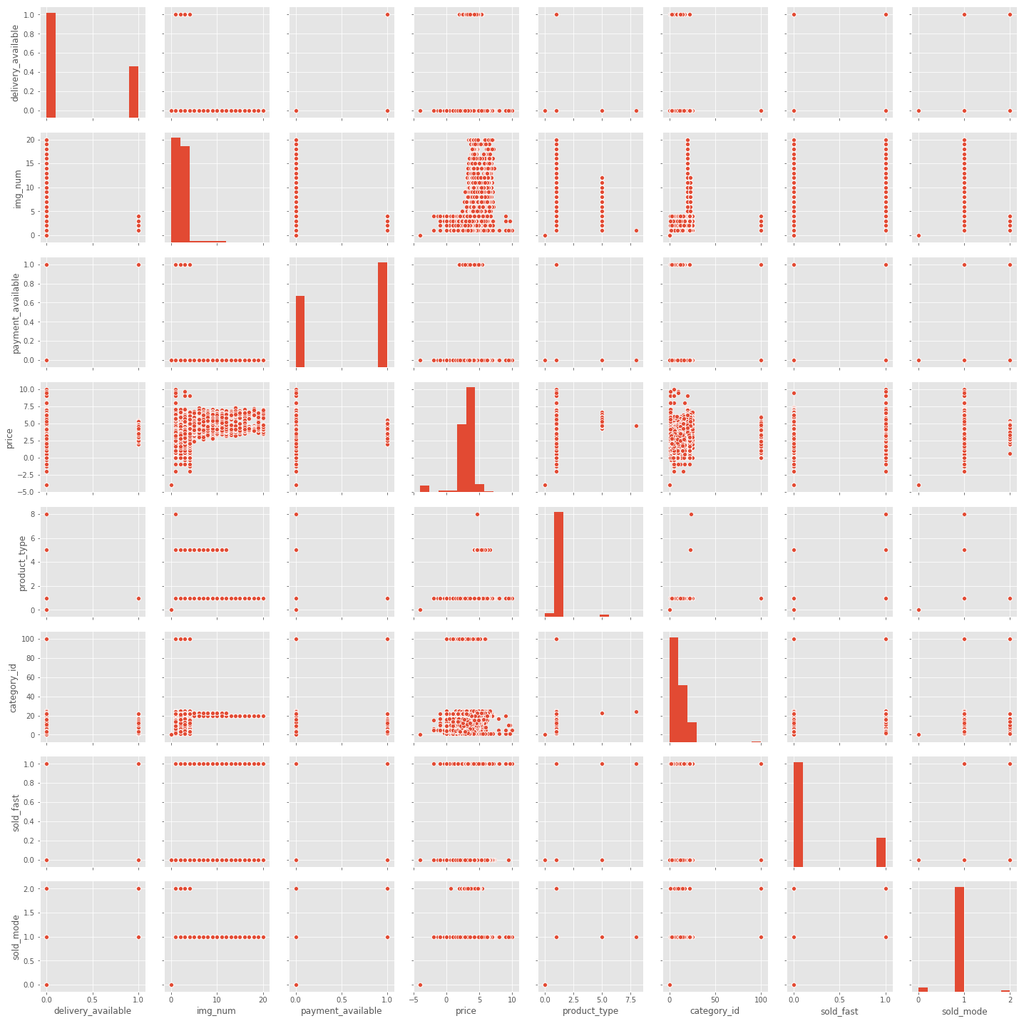

```python
# много графиков
sns.pairplot(df2)
```